# Data Wrangling and Visualisation

## 2.3 Combine datasets

### 2.3.1 Load other data

Let’s load some other datasets to analyse alongside our survey data.

**Total population counts** from [The World Bank](https://data.worldbank.org/indicator/SP.POP.TOTL), which we assign to variable `pops`:

```r
pops <- read_csv("../data/POP_TOTAL_DS2_en_v2.csv", skip = 4)

pops <- pops %>%
  rename(country = "Country Name", population = "2018") %>%
  select(country, population) %>% #we are only interested in these 2 columns
  mutate(iso3 = countrycode(country, origin = "country.name", destination = "iso3c"))
```

| country | population | iso3 |
| --- | --- | --- |
| Aruba | 105845 | ABW |
| Afghanistan | 37172386 | AFG |
| Angola | 30809762 | AGO |
| Albania | 2866376 | ALB |
| Andorra | 77006 | AND |
| Arab World | 419790588 | NA |
| United Arab Emirates | 9630959 | ARE |
| Argentina | 44494502 | ARG |
| Armenia | 2951776 | ARM |
| American Samoa | 55465 | ASM |
| Antigua and Barbuda | 96286 | ATG |
| Australia | 24992369 | AUS |
| Austria | 8847037 | AUT |
| Azerbaijan | 9942334 | AZE |
| Burundi | 11175378 | BDI |
| Belgium | 11422068 | BEL |
| Benin | 11485048 | BEN |
| Burkina Faso | 19751535 | BFA |
| Bangladesh | 161356039 | BGD |
| Bulgaria | 7024216 | BGR |
| Bahrain | 1569439 | BHR |
| Bahamas, The | 385640 | BHS |
| Bosnia and Herzegovina | 3323929 | BIH |
| Belarus | 9485386 | BLR |
| Belize | 383071 | BLZ |
| Bermuda | 63968 | BMU |
| Bolivia | 11353142 | BOL |
| Brazil | 209469333 | BRA |
| Barbados | 286641 | BRB |
| Brunei Darussalam | 428962 | BRN |

[output cut: 234 more lines]

Some country names could not be matched to a country code. Let’s see which values in `iso3` are `NA` values and remove them.

```r
which(is.na(pops$iso3)) #index of NA values
pops[is.na(pops$iso3),] #rows with NA values for iso3
```

```
## # A tibble: 49 × 3
##    country                                       population iso3
##    <chr>                                              <dbl> <chr>
##  1 Arab World                                     419790588 <NA>
##  2 Central Europe and the Baltics                 102511922 <NA>
##  3 Channel Islands                                   170499 <NA>
##  4 Caribbean small states                           7358965 <NA>
##  5 East Asia & Pacific (excluding high income)   2081651801 <NA>
##  6 Early-demographic dividend                    3249140605 <NA>
##  7 East Asia & Pacific                           2328220870 <NA>
##  8 Europe & Central Asia (excluding high income)  417797257 <NA>
##  9 Europe & Central Asia                          918793590 <NA>
## 10 Euro area                                      341783171 <NA>
## # … with 39 more rows
```

```r
pops <- pops[!is.na(pops$iso3),]

#alternatives:
pops <- pops[complete.cases(pops),] #only include rows that are complete!
na.omit(pops)
```

**Global Innovation Index** from [INSEAD](https://www.kaggle.com/harriken/insead-global-innovation-index/downloads/insead-global-innovation-index.zip/1), which we assign to variable `innov`:

```r
innov <- read_csv("../data/INSEADGlobalinnovationIndex2018.csv", skip = 0)

innov <- innov %>%
  rename(country = "Economy", index = "Score") %>%
  select(country, index) %>%
  mutate(iso3 = countrycode(country, origin = "country.name", destination = "iso3c"))
```

| country | index | iso3 |
| --- | --- | --- |
| Switzerland | 68.4 | CHE |
| Netherlands | 63.3 | NLD |
| Sweden | 63.1 | SWE |
| United Kingdom | 60.1 | GBR |
| Singapore | 59.8 | SGP |
| United States of America | 59.8 | USA |
| Finland | 59.6 | FIN |
| Denmark | 58.4 | DNK |
| Germany | 58.0 | DEU |
| Ireland | 57.2 | IRL |
| Israel | 56.8 | ISR |
| Korea, Republic of | 56.6 | KOR |
| Japan | 55.0 | JPN |
| Hong Kong (China) | 54.6 | HKG |
| Luxembourg | 54.5 | LUX |
| France | 54.4 | FRA |
| China | 53.1 | CHN |
| Canada | 53.0 | CAN |
| Norway | 52.6 | NOR |
| Australia | 52.0 | AUS |
| Austria | 51.3 | AUT |
| New Zealand | 51.3 | NZL |
| Iceland | 51.2 | ISL |
| Estonia | 50.5 | EST |
| Belgium | 50.5 | BEL |
| Malta | 50.3 | MLT |
| Czech Republic | 48.7 | CZE |
| Spain | 48.7 | ESP |
| Cyprus | 47.8 | CYP |
| Slovenia | 46.9 | SVN |

[output cut: 96 more lines]

### 2.3.2 Join country data

At this point, we have 3 summary tables with *‘countries’* as data points (each row):

1. `ctry_n` Number of survey respondents
2. `pops` Total population
3. `innov` Innovation index

Let’s combine these tables by country code (`iso3` column)

- The tables may have different countries from each other
- Let’s only keep the rows (countries) that are present in all 3 tables, using the function `inner_join()`
- Check out other ways to join tabular data using `?inner_join`

```r
ctry_data <- ctry_n %>%
  inner_join(innov, by = "iso3") %>%
  inner_join(pops, by = "iso3")
```

| iso3 | country.x | n | country.y | index | country | population |
| --- | --- | --- | --- | --- | --- | --- |
| ARG | Argentina | 119 | Argentina | 30.7 | Argentina | 44494502 |
| AUS | Australia | 330 | Australia | 52.0 | Australia | 24992369 |
| AUT | Austria | 62 | Austria | 51.3 | Austria | 8847037 |
| BEL | Belgium | 111 | Belgium | 50.5 | Belgium | 11422068 |
| BGD | Bangladesh | 107 | Bangladesh | 23.1 | Bangladesh | 161356039 |
| BLR | Belarus | 91 | Belarus | 29.4 | Belarus | 9485386 |
| BRA | Brazil | 736 | Brazil | 33.4 | Brazil | 209469333 |
| CAN | Canada | 604 | Canada | 53.0 | Canada | 37058856 |
| CHE | Switzerland | 164 | Switzerland | 68.4 | Switzerland | 8516543 |
| CHL | Chile | 76 | Chile | 37.8 | Chile | 18729160 |
| CHN | China | 1644 | China | 53.1 | China | 1392730000 |
| COL | Colombia | 128 | Colombia | 33.8 | Colombia | 49648685 |
| CZE | Czech Republic | 72 | Czech Republic | 48.7 | Czech Republic | 10625695 |
| DEU | Germany | 734 | Germany | 58.0 | Germany | 82927922 |
| DNK | Denmark | 106 | Denmark | 58.4 | Denmark | 5797446 |
| EGY | Egypt | 96 | Egypt | 27.2 | Egypt, Arab Rep. | 98423595 |
| ESP | Spain | 485 | Spain | 48.7 | Spain | 46723749 |
| FIN | Finland | 79 | Finland | 59.6 | Finland | 5518050 |
| FRA | France | 604 | France | 54.4 | France | 66987244 |
| GBR | United Kingdom of Great Britain and Northern Ireland | 702 | United Kingdom | 60.1 | United Kingdom | 66488991 |
| GRC | Greece | 121 | Greece | 38.9 | Greece | 10727668 |
| HKG | Hong Kong (S.A.R.) | 76 | Hong Kong (China) | 54.6 | Hong Kong SAR, China | 7451000 |
| HUN | Hungary | 93 | Hungary | 44.9 | Hungary | 9768785 |
| IDN | Indonesia | 171 | Indonesia | 29.8 | Indonesia | 267663435 |
| IND | India | 4417 | India | 35.2 | India | 1352617328 |
| IRL | Ireland | 101 | Ireland | 57.2 | Ireland | 4853506 |
| IRN | Iran, Islamic Republic of… | 113 | Iran, Islamic Republic of | 33.4 | Iran, Islamic Rep. | 81800269 |
| ISR | Israel | 173 | Israel | 56.8 | Israel | 8883800 |
| ITA | Italy | 355 | Italy | 46.3 | Italy | 60431283 |
| JPN | Japan | 597 | Japan | 55.0 | Japan | 126529100 |
| KEN | Kenya | 85 | Kenya | 31.1 | Kenya | 51393010 |
| KOR | Republic of Korea | 259 | Korea, Republic of | 56.6 | Korea, Rep. | 51635256 |
| MAR | Morocco | 71 | Morocco | 31.1 | Morocco | 36029138 |
| MEX | Mexico | 202 | Mexico | 35.3 | Mexico | 126190788 |
| MYS | Malaysia | 113 | Malaysia | 43.0 | Malaysia | 31528585 |
| NGA | Nigeria | 208 | Nigeria | 22.4 | Nigeria | 195874740 |
| NLD | Netherlands | 270 | Netherlands | 63.3 | Netherlands | 17231017 |
| NOR | Norway | 74 | Norway | 52.6 | Norway | 5314336 |
| NZL | New Zealand | 77 | New Zealand | 51.3 | New Zealand | 4885500 |
| PAK | Pakistan | 161 | Pakistan | 24.1 | Pakistan | 212215030 |
| PER | Peru | 81 | Peru | 31.8 | Peru | 31989256 |
| PHL | Philippines | 73 | Philippines | 31.6 | Philippines | 106651922 |
| POL | Poland | 301 | Poland | 41.7 | Poland | 37978548 |
| PRT | Portugal | 155 | Portugal | 45.7 | Portugal | 10281762 |
| ROU | Romania | 79 | Romania | 37.6 | Romania | 19473936 |
| RUS | Russia | 879 | Russian Federation | 37.9 | Russian Federation | 144478050 |
| SGP | Singapore | 186 | Singapore | 59.8 | Singapore | 5638676 |
| SWE | Sweden | 155 | Sweden | 63.1 | Sweden | 10183175 |
| THA | Thailand | 73 | Thailand | 38.0 | Thailand | 69428524 |
| TUN | Tunisia | 74 | Tunisia | 32.9 | Tunisia | 11565204 |
| TUR | Turkey | 327 | Turkey | 37.4 | Turkey | 82319724 |
| UKR | Ukraine | 252 | Ukraine | 38.5 | Ukraine | 44622516 |
| USA | United States of America | 4716 | United States of America | 59.8 | United States | 327167434 |
| VNM | Viet Nam | 144 | Viet Nam | 37.9 | Vietnam | 95540395 |
| ZAF | South Africa | 147 | South Africa | 35.1 | South Africa | 57779622 |

- The colname `country` are also common across the 3 tables. These duplicate variables are given a suffix in the new table.
- Since the naming of countries are not always similar, joining tables by country code `iso3` gives us a larger dataset
- We can choose to keep the colname `country` only and discard the other two.

```r
ctry_data <- subset(ctry_data, select = -c(country.x,country.y))
```

- Let’s save this summary table `ctry_data` on our computer!

```r
write_csv(ctry_data, "../output/country_data.csv",
          append = FALSE, #overwrites existing file if present
          col_names = TRUE) #writes colnames as headers
```

## 2.4 Respondents per population

Let’s calculate the number of respondents as a proportion of the total population in each country.

- Possible proxy for interest/prevalence of data science in each country
- Save it in a new colname `respop10k`.

```r
ctry_data$respop10k <- ctry_data$n / ctry_data$population * 10000 #respondents per 10k
```

Now let’s visualise this new column `respop10k`. This time, let’s plot it in a bar chart instead of in a world map. But before that, we can specify some design (color) customisations in a new column we’ll call `label`.

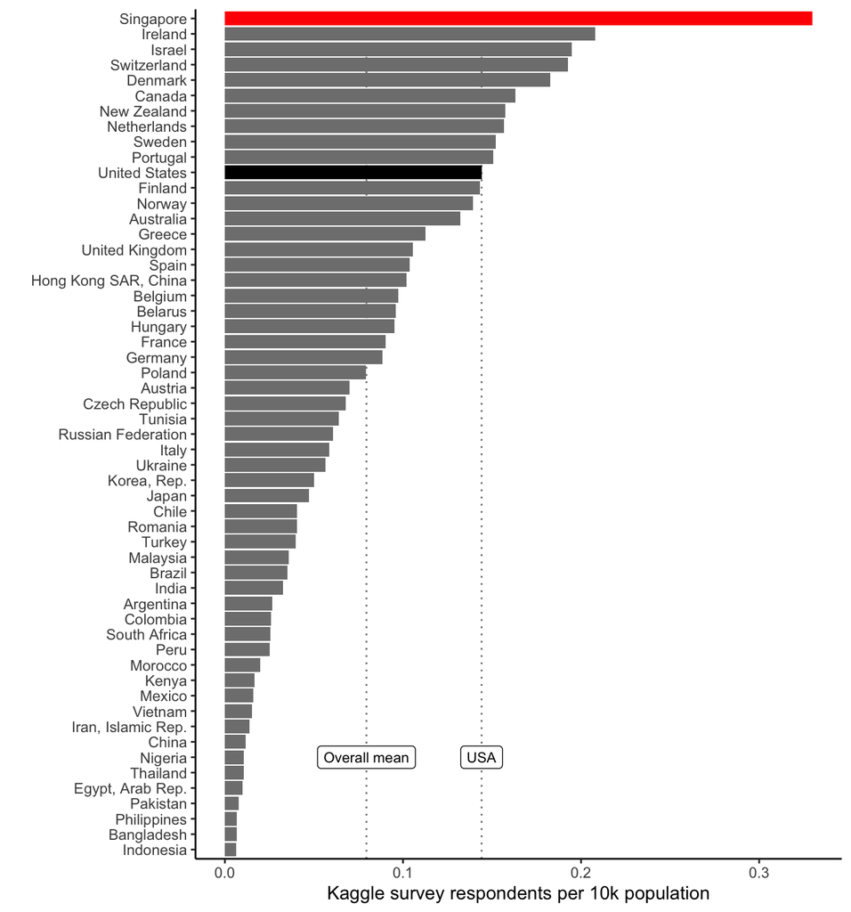

```r
#design customisations: barplot color
ctry_data$label <- c("normal")
ctry_data[ctry_data$iso3=="USA",]$label = c("benchmark")
ctry_data[ctry_data$iso3=="SGP",]$label = c("highlight")
ctry_data$label <- factor(ctry_data$label, levels = c("normal", "benchmark", "highlight")) #convert to factor with specified levels
cols <- c("grey50","black","red") #create vector of corresponding colors

#plot
ctryplot <- ctry_data %>%
  ggplot(aes(x = reorder(country, respop10k), #plot countries in desc order
             y = respop10k,
             fill = label)) + #barplot fill color

  geom_hline(yintercept = c(ctry_data$respop10k[ctry_data$iso3=="USA"], #vertical lines
                            mean(ctry_data$respop10k)),
             linetype = "dotted",
             color = "grey50") +
  geom_col() + #barplot

  scale_fill_manual(values = cols) + #values from 'cols' vector mapped to 'fill' aesthetic

  #customisation
  labs(x = "", y = "Kaggle survey respondents per 10k population") +

  coord_flip()  + #switch x & y axis

  theme(legend.position = "none",
        panel.grid.major = element_blank(),
        panel.grid.minor = element_blank(),
        panel.background = element_blank(),
        axis.line = element_line(colour = "black")) +

  annotate("label", x = 7, y = ctry_data$respop10k[ctry_data$iso3=="USA"], label = "USA",size=3, color="black") +
  annotate("label", x = 7, y = mean(ctry_data$respop10k), label = "Overall mean",size=3, color="black")

print(ctryplot)
```

- We can save the plot to an image file using `jpeg()`, `tiff()`, `png()`, etc.
- Run the following code chunk at one go

```r
jpeg(filename = "../output/ctryplot.jpeg", width = 1800, height = 2000, res = 300)
print(ctryplot)
dev.off() #finish creating the image file
```

## 2.5 Innovation

[figure not shown]

```r
library(ggrepel)

ggplot(ctry_data, aes(x = respop10k,
                     y = index,
                     color = label,
                     label = country)) +
  geom_point() + #plot points
  geom_text_repel() + #plot text label using function from library(ggrepel)

  scale_color_manual(values = cols) + #values from 'cols' vector mapped to 'color' aesthetic

  #customisation
  labs(y = "Global Innovation Index",
       x = "Kaggle survey respondents per 10k population") +
  theme(legend.position = "none",
        panel.grid.major = element_blank(),
        panel.grid.minor = element_blank(),
        panel.background = element_blank(),
        axis.line = element_line(colour = "black",
        arrow = arrow(length = unit(0.08, "inches"), type = "open")))
```

- According to the [Global Innovation Index](https://www.kaggle.com/harriken/insead-global-innovation-index/downloads/insead-global-innovation-index.zip/1), Switzerland was the most innovative country in 2018.

```r
#calculate correlation
cor_results <- cor.test(ctry_data$respop10k, ctry_data$index,
                        method = "spearman") #ranked comparisons
```

- The correlation between the two variables is 0.797 (P = 3.36e-13)

```r
#remove objects from r
rm(cor_results, ctry_data, ctry_n, ctryplot, innov, multi, pops, cols)
```

# 3 Further applications

**Data communication**

- Interactive plots with [Plotly](https://plot.ly/r/)
- Visualisation with the [rCharts](http://www.rpubs.com/dnchari/rcharts) package
- Interactive web apps with [Shiny](https://shiny.rstudio.com)
- Alternative outputs for [R Markdown](https://bookdown.org/yihui/rmarkdown/) documents

**Statistics in R**

- r-statistics.co by Selva Prabhakaran
- [R Tutorial: An Introduction to Statistics](http://www.r-tutor.com/elementary-statistics)
- [Learning Statistics with R](https://learningstatisticswithr.com) by Danielle Navarro
- [Statistics Fundamentals with R](https://www.datacamp.com/tracks/learn-statistics-with-r) by Datacamp
- [Statistics and R](https://online-learning.harvard.edu/course/statistics-and-r) by Havard University

**Other resources**

- [Skill tracks in R](https://www.datacamp.com/tracks/skill) by Datacamp

Copyright © 2022 Song, Xiao Ping